# Problem Set 3

Written By Yunqiu (Julie) Li, in Autumn 2018

## Question 7.1

### a.

```r
# regression 1: Birthweight on Smoker
reg_1 <-lm(birthweight~smoker, data = birthweight_smoking)
coeftest(reg_1, vcov = vcovHC(reg_1, type = "HC1"))
```

```
##
## t test of coefficients:
##
##             Estimate Std. Error  t value  Pr(>|t|)
## (Intercept) 3432.060     11.891 288.6380 < 2.2e-16 ***
## smoker      -253.228     26.810  -9.4452 < 2.2e-16 ***
## ---
## Signif. codes:  0 '***' 0.001 '**' 0.01 '*' 0.05 '.' 0.1 ' ' 1
```

```r
# regression 2: Birthweight on Smoker, Alcohol, and Nprevist
reg_2 <-lm(birthweight~smoker+alcohol+nprevist, data = birthweight_smoking)
coeftest(reg_2, vcov = vcovHC(reg_2, type = "HC1"))
```

```
##
## t test of coefficients:
##
##              Estimate Std. Error t value Pr(>|t|)
## (Intercept) 3051.2486    43.7145  69.799   <2e-16 ***
## smoker      -217.5801    26.1076  -8.334   <2e-16 ***
## alcohol      -30.4913    72.5967  -0.420   0.6745
## nprevist      34.0699     3.6083   9.442   <2e-16 ***
## ---
## Signif. codes:  0 '***' 0.001 '**' 0.01 '*' 0.05 '.' 0.1 ' ' 1
```

```r
# regression 3: Birthweight on Smoker, Alcohol, Nprevist, and Unmarried
reg_3 <-lm(birthweight~smoker+alcohol+nprevist+unmarried, data = birthweight_smoking)
coeftest(reg_3, vcov = vcovHC(reg_3, type = "HC1"))
```

```
##
## t test of coefficients:
##
##              Estimate Std. Error t value  Pr(>|t|)
## (Intercept) 3134.4000    44.1486 70.9966 < 2.2e-16 ***
## smoker      -175.3769    26.8268 -6.5374 7.333e-11 ***
## alcohol      -21.0835    72.9921 -0.2888    0.7727
## nprevist      29.6025     3.5827  8.2625 < 2.2e-16 ***
## unmarried   -187.1332    27.6772 -6.7613 1.638e-11 ***
## ---
## Signif. codes:  0 '***' 0.001 '**' 0.01 '*' 0.05 '.' 0.1 ' ' 1
```

The estimated effect of smoking on birth weight in the first regression is -253.228. The estimated effect of smoking on birth weight in the second regression is -217.580. The estimated effect of smoking on birth weight in the third regression is -175.377.

### b.

```r
# 95% confidenct interval = [estimated coefficient +/- (1.96*sdr. error for estimated coefficient)]
# CI for regression 1
c(-253.228 - 1.96*26.810, -253.228 + 1.96*26.810)
```

```
## [1] -305.7756 -200.6804
```

```r
# CI for regression 2
c(-217.5801 - 1.96*26.1076, -217.5801 + 1.96*26.1076)
```

```
## [1] -268.7510 -166.4092
```

```r
# CI for regression 3
c(-175.3769 - 1.96*26.8268, -175.3769 + 1.96*26.8268)
```

```
## [1] -227.9574 -122.7964
```

The 95% confidence interval for the effect of smoking on birth weight in regression 1 is [-305.7756, -200.6804]. The 95% confidence interval for the effect of smoking on birth weight in regression 2 is [-268.7510, -166.4092]. The 95% confidence interval for the effect of smoking on birth weight in regression 3 is [-227.9574, -122.7964].

### c.

```r
# Compare coffecient and adjusted R-squared for regression 1&2
summary(reg_1)
```

```
##
## Call:
## lm(formula = birthweight ~ smoker, data = birthweight_smoking)
##
## Residuals:
##      Min       1Q   Median       3Q      Max
## -3007.06  -313.06    26.94   366.94  2322.94
##
## Coefficients:
##             Estimate Std. Error t value Pr(>|t|)
## (Intercept)  3432.06      11.87 289.115   <2e-16 ***
## smoker       -253.23      26.95  -9.396   <2e-16 ***
## ---
## Signif. codes:  0 '***' 0.001 '**' 0.01 '*' 0.05 '.' 0.1 ' ' 1
##
## Residual standard error: 583.7 on 2998 degrees of freedom
## Multiple R-squared:  0.0286, Adjusted R-squared:  0.02828
## F-statistic: 88.28 on 1 and 2998 DF,  p-value: < 2.2e-16
```

```r
summary(reg_2)
```

```
##
## Call:
## lm(formula = birthweight ~ smoker + alcohol + nprevist, data = birthweight_smoking)
##
## Residuals:
##      Min       1Q   Median       3Q      Max
## -2733.53  -307.57    21.42   358.09  2192.70
##
## Coefficients:
##             Estimate Std. Error t value Pr(>|t|)
## (Intercept) 3051.249     34.016  89.701  < 2e-16 ***
## smoker      -217.580     26.680  -8.155 5.07e-16 ***
## alcohol      -30.491     76.234  -0.400    0.689
## nprevist      34.070      2.855  11.933  < 2e-16 ***
## ---
## Signif. codes:  0 '***' 0.001 '**' 0.01 '*' 0.05 '.' 0.1 ' ' 1
##
## Residual standard error: 570.5 on 2996 degrees of freedom
## Multiple R-squared:  0.07285,    Adjusted R-squared:  0.07192
## F-statistic: 78.47 on 3 and 2996 DF,  p-value: < 2.2e-16
```

Regression 1 suffers from omitted variable bias. Alcohol and nprevist are very like to be correlated with smoker and they are also potential determinants of birthweight. We can also tell that from the two regressions above. As alcohol and nprevist are added to regression 2, the coefficent of smoker increases from -253.23 to -217.580, and the adjusted R-squared increases from 0.02828 to 0.07192, which indicates that regression 2 is a better estimator for birthweight. The adjusted R-squared increases because two more regressors(alcohol and nprevist) are added to the regression, which adjusts some of the omitted variable bias.

### d.

```r
# Compare coffecient and adjusted R-squared for regression 2&3
summary(reg_2)
```

```
##
## Call:
## lm(formula = birthweight ~ smoker + alcohol + nprevist, data = birthweight_smoking)
##
## Residuals:
##      Min       1Q   Median       3Q      Max
## -2733.53  -307.57    21.42   358.09  2192.70
##
## Coefficients:
##             Estimate Std. Error t value Pr(>|t|)
## (Intercept) 3051.249     34.016  89.701  < 2e-16 ***
## smoker      -217.580     26.680  -8.155 5.07e-16 ***
## alcohol      -30.491     76.234  -0.400    0.689
## nprevist      34.070      2.855  11.933  < 2e-16 ***
## ---
## Signif. codes:  0 '***' 0.001 '**' 0.01 '*' 0.05 '.' 0.1 ' ' 1
##
## Residual standard error: 570.5 on 2996 degrees of freedom
## Multiple R-squared:  0.07285,    Adjusted R-squared:  0.07192
## F-statistic: 78.47 on 3 and 2996 DF,  p-value: < 2.2e-16
```

```r
summary(reg_3)
```

```
##
## Call:
## lm(formula = birthweight ~ smoker + alcohol + nprevist + unmarried,
##     data = birthweight_smoking)
##
## Residuals:
##      Min       1Q   Median       3Q      Max
## -2798.81  -309.22    25.37   361.80  2363.70
##
## Coefficients:
##             Estimate Std. Error t value Pr(>|t|)
## (Intercept) 3134.400     35.656  87.907  < 2e-16 ***
## smoker      -175.377     27.099  -6.472 1.13e-10 ***
## alcohol      -21.083     75.607  -0.279     0.78
## nprevist      29.603      2.898  10.213  < 2e-16 ***
## unmarried   -187.133     26.007  -7.195 7.84e-13 ***
## ---
## Signif. codes:  0 '***' 0.001 '**' 0.01 '*' 0.05 '.' 0.1 ' ' 1
##
## Residual standard error: 565.7 on 2995 degrees of freedom
## Multiple R-squared:  0.08861,    Adjusted R-squared:  0.08739
## F-statistic: 72.79 on 4 and 2995 DF,  p-value: < 2.2e-16
```

Regression 2 also suffers from omitted variable bias. Unmarried are very like to be correlated with smoker and it is also potential determinant of birthweight. We can also tell that from the two regressions above. As unmarried is added to regression 3, the coefficent of smoker increases from -217.580 to -175.377, and the adjusted R-squared increases from 0.07192 to 0.08739, which indicates that regression 3 is the best estimator for birthweight among three regressions. The adjusted R-squared increases because regressor unmarried is added to the regression, which adjusts some of the omitted variable bias.

### e.

```r
# i.
confint(reg_3,"unmarried",level=0.95)
```

```
##               2.5 %    97.5 %
## unmarried -238.1276 -136.1389
```

```r
# ii.
# generate coefficient and p-value for unmarred in regression 3
coeftest(reg_3, vcov = vcovHC(reg_3, type = "HC1"))
```

```
##
## t test of coefficients:
##
##              Estimate Std. Error t value  Pr(>|t|)
## (Intercept) 3134.4000    44.1486 70.9966 < 2.2e-16 ***
## smoker      -175.3769    26.8268 -6.5374 7.333e-11 ***
## alcohol      -21.0835    72.9921 -0.2888    0.7727
## nprevist      29.6025     3.5827  8.2625 < 2.2e-16 ***
## unmarried   -187.1332    27.6772 -6.7613 1.638e-11 ***
## ---
## Signif. codes:  0 '***' 0.001 '**' 0.01 '*' 0.05 '.' 0.1 ' ' 1
```

The coefficient for unmarried in regression 3 is statistically significant, because the coefficient -187.1332 is within the 95% confidence internval for the coefficient. Also, the absolute value for t-stat for unmarried is 6.7613, which is greater than the critical value of 2.58, so the coefficient for unmarried in regression 3 is also statistically significant at 1% significant level.

3. The magnitude of the coefficient is large. From the above regression result, we can tell that unmarried actually have the biggest effect on birthweight compared with the other varaibles do, because the abosulte value for its coefficient is the greatest among the absoluate value for all the variables coefficient.
4. I disagree that the large coefficient suggests that public policies that encourage marriage will lead, on average, to healthier babies. Because unmarried is a control variable that controls for factors like nutritious intakes. Marriage will generately improve the financial situation of the family as the couples both have income sources, which wil enable mothers in those families to have greater access to nutritious intakes.Therefore, in this situation, the control variable unmarriage remains correlated with the error term, so the coefficient on unmarried is subjected to omitted variable bias and does not have a casual interpretation.

### f.

```r
# Initial Regression
reg_4 <-lm(birthweight~smoker+alcohol+nprevist+unmarried+drinks+tripre1+tripre2+tripre3, data = birthweight_smoking)
coeftest(reg_4, vcov = vcovHC(reg_4, type = "HC1"))
```

```
##
## t test of coefficients:
##
##               Estimate Std. Error t value  Pr(>|t|)
## (Intercept) 2886.23751  139.85876 20.6368 < 2.2e-16 ***
## smoker      -178.28232   26.69228 -6.6792 2.854e-11 ***
## alcohol        0.91422   90.82855  0.0101   0.99197
## nprevist      32.10346    4.25229  7.5497 5.758e-14 ***
## unmarried   -198.98878   28.54451 -6.9712 3.851e-12 ***
## drinks        -3.43701   16.46237 -0.2088   0.83463
## tripre1      210.62611  149.05287  1.4131   0.15773
## tripre2      271.84108  146.95189  1.8499   0.06443 .
## tripre3      386.79617  155.73297  2.4837   0.01306 *
## ---
## Signif. codes:  0 '***' 0.001 '**' 0.01 '*' 0.05 '.' 0.1 ' ' 1
```

```r
# Updated Regression
reg_5 <-lm(birthweight~smoker+alcohol+nprevist+unmarried+tripre2+tripre3, data = birthweight_smoking)
coeftest(reg_5, vcov = vcovHC(reg_5, type = "HC1"))
```

```
##
## t test of coefficients:
##
##              Estimate Std. Error t value  Pr(>|t|)
## (Intercept) 3069.4571    50.4900 60.7934 < 2.2e-16 ***
## smoker      -179.2665    26.7421 -6.7035 2.422e-11 ***
## alcohol      -19.4393    71.8908 -0.2704  0.786871
## nprevist      34.3301     4.0234  8.5326 < 2.2e-16 ***
## unmarried   -204.3785    28.4673 -7.1794 8.793e-13 ***
## tripre2       72.5987    33.2993  2.1802  0.029321 *
## tripre3      197.0834    73.8470  2.6688  0.007653 **
## ---
## Signif. codes:  0 '***' 0.001 '**' 0.01 '*' 0.05 '.' 0.1 ' ' 1
```

```r
# 95% confidence interval
confint(reg_5,"smoker",level=0.95)
```

```
##            2.5 %    97.5 %
## smoker -232.3486 -126.1843
```

I think variables tripre2 and tripre3 should also be included in the regression. Initially, I think tripre1, tripre2, tripre3 and drinks should all be included in the regression, because the time for prenatal care visit and the numbers of drink would affect birthweight. However, the coefficient for these two variables are not statistically significant. The coefficients for tripre2 and tripre3 are statistically significant. The 95% confidence interval for the effect of smoking on birthweight is [-232.3486, -126.1843].

## Question 8.2

### a.

```r
# regression of average hourly earnings (AHE) on age (Age), gender (Female), and education (Bachelor)
reg_ahe_1 <- lm(ahe~age+female+bachelor, data = cps12)
coeftest(reg_ahe_1, vcov = vcovHC(reg_ahe_1, type = "HC1"))
```

```
##
## t test of coefficients:
##
##              Estimate Std. Error  t value Pr(>|t|)
## (Intercept)  1.866198   1.175373   1.5877   0.1124
## age          0.510286   0.039541  12.9053   <2e-16 ***
## female      -3.810305   0.223915 -17.0168   <2e-16 ***
## bachelor     8.318628   0.223733  37.1811   <2e-16 ***
## ---
## Signif. codes:  0 '***' 0.001 '**' 0.01 '*' 0.05 '.' 0.1 ' ' 1
```

Based on the above regression output，if Age increases from 25 to 26, earnings are expected to increase 0.51. Similarly, if Age increases from 33 to 34, earnings are also expected to increase 0.51. The regression model above is a linear model. Therefore, the coefficient on age indicates the effect of Age on AHE when age change by one unit, which is 0.51.

### b.

```r
# add column of log(ahe) in dataset
cps12 <- cps12 %>% mutate(logearning = log(ahe))
# log-linear regression. Run a regression of the logarithm of average hourly earnings, ln(AHE), on Age, Female, and Bachelor.
reg_ahe_2 <- lm(logearning~age+female+bachelor, data = cps12)
coeftest(reg_ahe_2, vcov = vcovHC(reg_ahe_2, type = "HC1"))
```

```
##
## t test of coefficients:
##
##               Estimate Std. Error t value  Pr(>|t|)
## (Intercept)  1.9414232  0.0590018  32.904 < 2.2e-16 ***
## age          0.0255179  0.0019619  13.007 < 2.2e-16 ***
## female      -0.1923376  0.0112614 -17.079 < 2.2e-16 ***
## bachelor     0.4377833  0.0112003  39.087 < 2.2e-16 ***
## ---
## Signif. codes:  0 '***' 0.001 '**' 0.01 '*' 0.05 '.' 0.1 ' ' 1
```

If Age increases from 25 to 26, earnings are expected to increase by 2.55%. If Age increases from 33 to 34, earnings are also expected to increase by 2.55%.

### c.

```r
# add column of log(age) in dataset
cps12 <- cps12 %>% mutate(logage = log(age))
# Run a regression of the logarithm of average hourly earnings, ln(AHE), on ln(Age), Female, and Bachelor.
reg_ahe_3 <- lm(logearning~logage+female+bachelor, data = cps12)
coeftest(reg_ahe_3, vcov = vcovHC(reg_ahe_3, type = "HC1"))
```

```
##
## t test of coefficients:
##
##              Estimate Std. Error  t value Pr(>|t|)
## (Intercept)  0.149532   0.195339   0.7655    0.444
## logage       0.752941   0.057615  13.0684   <2e-16 ***
## female      -0.192356   0.011259 -17.0842   <2e-16 ***
## bachelor     0.437664   0.011199  39.0795   <2e-16 ***
## ---
## Signif. codes:  0 '***' 0.001 '**' 0.01 '*' 0.05 '.' 0.1 ' ' 1
```

If Age increases from 25 to 26(4%), earnings are expected to increase by 4 x 0.753% = 3.012%. If Age increases from 33 to 34(3.03%), earnings are also expected to increase by 3.03 x 0.753% = 2.282%.

### d.

```r
# add column of age^2 in dataset
cps12 <- cps12 %>% mutate(squareage = age^2)
# Run a regression of the logarithm of average hourly earnings, ln(AHE), on Age, Age^2, Female, and Bachelor.
reg_ahe_4 <- lm(logearning~age+squareage+female+bachelor, data = cps12)
coeftest(reg_ahe_4, vcov = vcovHC(reg_ahe_4, type = "HC1"))
```

```
##
## t test of coefficients:
##
##                Estimate  Std. Error  t value Pr(>|t|)
## (Intercept)  0.79188188  0.67126087   1.1797  0.23816
## age          0.10404487  0.04573137   2.2751  0.02293 *
## squareage   -0.00132843  0.00077278  -1.7190  0.08565 .
## female      -0.19239833  0.01125894 -17.0885  < 2e-16 ***
## bachelor     0.43741212  0.01120964  39.0211  < 2e-16 ***
## ---
## Signif. codes:  0 '***' 0.001 '**' 0.01 '*' 0.05 '.' 0.1 ' ' 1
```

```r
# Caculate change in AHE if age increases from 25 to 26
1*0.104 + (26^2-25^2)*(-0.001328)
```

```
## [1] 0.036272
```

```r
# Caculate change in AHE if age increases from 33 to 34
1*0.104 + (34^2-33^2)*(-0.001328)
```

```
## [1] 0.015024
```

If Age increases from 25 to 26, earnings are expected to increase by 3.63%. If Age increases from 33 to 34(3.03%), earnings are also expected to increase by 1.50%.

### e.

```r
# get adjusted R-square for regression in b
summary.lm(reg_ahe_2)["adj.r.squared"][[1]]
```

```
## [1] 0.19606
```

```r
# get adjusted R-square for regression in c
summary.lm(reg_ahe_3)["adj.r.squared"][[1]]
```

```
## [1] 0.1962391
```

I prefer regression (c) over regression (b) because the adjusted r-squared for regression (c)(0.1962391) is greater than the adjusted r-squared for regression (b)(0.19606). Therefore, regression (c) has a better fit.

### f.

```r
# get adjusted R-square for regression in b
summary.lm(reg_ahe_2)["adj.r.squared"][[1]]
```

```
## [1] 0.19606
```

```r
# get adjusted R-square for regression in d
summary.lm(reg_ahe_4)["adj.r.squared"][[1]]
```

```
## [1] 0.1962726
```

### g.

```r
# get adjusted R-square for regression in c
summary.lm(reg_ahe_3)["adj.r.squared"][[1]]
```

```
## [1] 0.1962391
```

```r
# get adjusted R-square for regression in d
summary.lm(reg_ahe_4)["adj.r.squared"][[1]]
```

```
## [1] 0.1962726
```

### h.

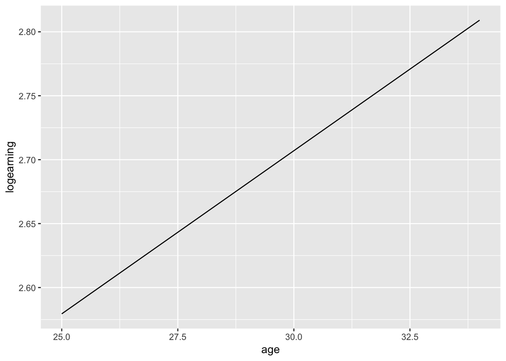

```r
# plot for regression in (b)
library(ggplot2)
plot_b<-function(x)1.94142 + 0.02552*x
ggplot(reg_ahe_2, aes(x = age, y = logearning))+
  stat_function(fun = plot_b)
```

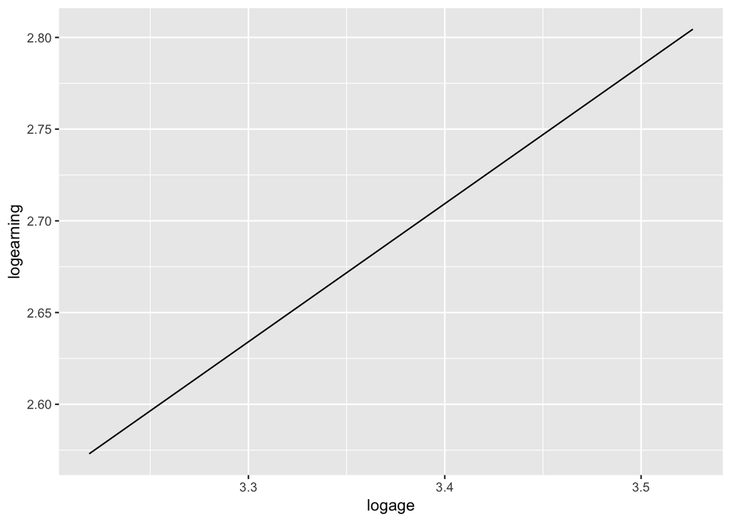

```r
# plot for regression in (c)
plot_c<-function(x)0.1495 +0.7529*x
ggplot(reg_ahe_3, aes(x = logage, y = logearning))+
  stat_function(fun = plot_c)
```

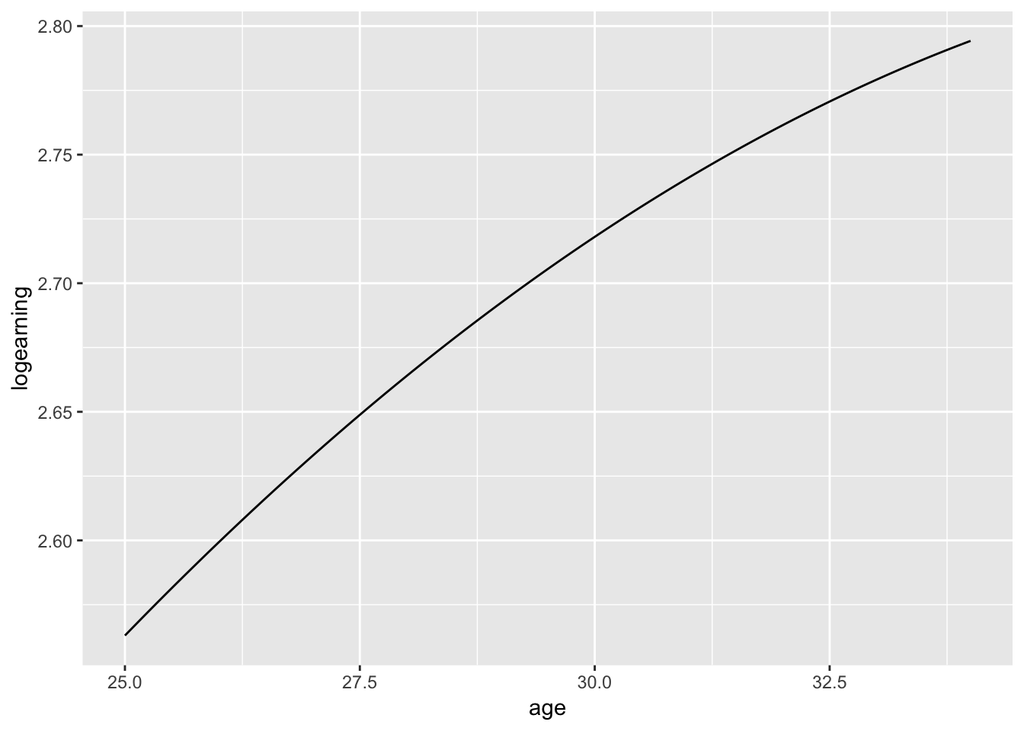

```r
# plot for regression in (d)
plot_d<-function(x) 0.791882 + 0.104045*x -0.001328*x^2
ggplot(reg_ahe_4, aes(x = age, y = logearning))+
  stat_function(fun = plot_d)
```

Plot b and plot c have straight lines and are quite similar as there is linear relatinship between log of AHE(logearning) and age or log of age. The slopes for plot b and plot c are constant. However, plot d is a curve line, which indicates the non-linear relationship between log of AHE and age. This is generated due to the addition of regressor squareage(the square of age). The slope for plot d decreases as the value of age increases.

My answer would not change if I plot the regression function for females with college degrees. Because there are no interaction terms in all the three regressions, the effect of age on In(ahe) will not depend on the binary variable female.

### i.

```r
# add column female*bachelor to dataset
cps12 <- cps12 %>% mutate(female_bachelor = female*bachelor)
reg_ahe_5 <- lm(logearning~age+squareage+female+bachelor+female_bachelor, data = cps12)
coeftest(reg_ahe_5, vcov = vcovHC(reg_ahe_5, type = "HC1"))
```

```
##
## t test of coefficients:
##
##                    Estimate  Std. Error  t value  Pr(>|t|)
## (Intercept)      0.80374070  0.67064489   1.1985   0.23078
## age              0.10432241  0.04568001   2.2838   0.02241 *
## squareage       -0.00133158  0.00077188  -1.7251   0.08455 .
## female          -0.24237318  0.01663764 -14.5678 < 2.2e-16 ***
## bachelor         0.40044634  0.01484824  26.9693 < 2.2e-16 ***
## female_bachelor  0.08985710  0.02255924   3.9832 6.865e-05 ***
## ---
## Signif. codes:  0 '***' 0.001 '**' 0.01 '*' 0.05 '.' 0.1 ' ' 1
```

```r
# In(ahe) for Alexis
ahe_Alexis = 0.80374070 + 30*0.10432241-0.00133158*30^2-0.24237318 *1+0.40044634*1+0.08985710*1*1
ahe_Alexis
```

```
## [1] 2.982921
```

```r
# In(ahe) for Jane
ahe_Jane =  0.80374070 + 30*0.10432241-0.00133158*30^2-0.24237318 *1+0.40044634*0+0.08985710*1*0
ahe_Jane
```

```
## [1] 2.492618
```

```r
# difference between In(ahe) for Alexis and In(ahe) for Jane
difference_1 = ahe_Alexis-ahe_Jane
difference_1
```

```
## [1] 0.4903034
```

```r
# In(ahe) for Bob
ahe_Bob = 0.80374070 + 30*0.10432241-0.00133158*30^2-0.08985710*0+0.40044634*1+0.08985710*0*1
ahe_Bob
```

```
## [1] 3.135437
```

```r
# In(ahe) for Jim
ahe_Jim = 0.80374070 + 30*0.10432241-0.00133158*30^2-0.08985710*0+0.40044634*0+0.08985710*0*0
ahe_Jim
```

```
## [1] 2.734991
```

```r
# difference between In(ahe) for Bob and In(ahe) for Jim
difference_2 = ahe_Bob-ahe_Jim
difference_2
```

```
## [1] 0.4004463
```

The coefficient on internaction term(0.0899) measures the difference of effect of having a bachelor degree on In(ahe) for female vs. male.

### j.

```r
# add columns female*age, femalge*(age^2) to dataset
cps12 <- cps12 %>% mutate(female_age = female*age, female_agesquare = female*age*age)
reg_ahe_6 <- lm(logearning~age+squareage+female+bachelor+female_bachelor+female_age+female_agesquare, data = cps12)
coeftest(reg_ahe_6, vcov = vcovHC(reg_ahe_6, type = "HC1"))
```

```
##
## t test of coefficients:
##
##                     Estimate  Std. Error t value  Pr(>|t|)
## (Intercept)       1.98705568  0.88336456  2.2494   0.02452 *
## age               0.02024576  0.06016720  0.3365   0.73651
## squareage         0.00014415  0.00101658  0.1418   0.88724
## female           -2.94932977  1.35577798 -2.1754   0.02963 *
## bachelor          0.40076286  0.01484872 26.9897 < 2.2e-16 ***
## female_bachelor   0.08860228  0.02257169  3.9254 8.738e-05 ***
## female_age        0.19254668  0.09235169  2.0849   0.03711 *
## female_agesquare -0.00338315  0.00156048 -2.1680   0.03019 *
## ---
## Signif. codes:  0 '***' 0.001 '**' 0.01 '*' 0.05 '.' 0.1 ' ' 1
```

Yes, the effect of Age on earnings is different for men than for women. Through adding two more interaction terms into the regression(female_age, female_agesquare), we can tell that the t-stat for these two variables are statistically significant at 5% level.

### k.

```r
# add columns bachelor*age, bachelor*(age^2) to dataset
cps12 <- cps12 %>% mutate(bachelor_age = bachelor*age, bachelor_agesquare = bachelor*age*age)
reg_ahe_7 <- lm(logearning~age+squareage+female+bachelor+female_bachelor+bachelor_age+bachelor_agesquare, data = cps12)
coeftest(reg_ahe_7, vcov = vcovHC(reg_ahe_7, type = "HC1"))
```

```
##
## t test of coefficients:
##
##                       Estimate  Std. Error  t value  Pr(>|t|)
## (Intercept)         1.81017174  0.94901088   1.9074    0.0565 .
## age                 0.03737279  0.06466958   0.5779    0.5633
## squareage          -0.00022869  0.00109314  -0.2092    0.8343
## female             -0.24231614  0.01663762 -14.5643 < 2.2e-16 ***
## bachelor           -1.52942634  1.34023141  -1.1412    0.2538
## female_bachelor     0.08999894  0.02257085   3.9874 6.744e-05 ***
## bachelor_age        0.12837980  0.09127050   1.4066    0.1596
## bachelor_agesquare -0.00211527  0.00154236  -1.3715    0.1703
## ---
## Signif. codes:  0 '***' 0.001 '**' 0.01 '*' 0.05 '.' 0.1 ' ' 1
```

No, the effect of Age on earnings is not different for high school graduates than for college graduates. Through adding two more interaction terms into the regression(bachelor_age, bachelor_agesquare), we can tell that the t-stat for these two variables are not statistically significant at any level.